# Homework

## A-21039-2021-09-30

5.4:

基本的mc运用

```r
mcBeta <- function(n,x){
  y<-runif(n,0,x);
  mc<-30*x*mean((y*(1-y))^2);
  return(mc)
  } ## n为计算次数,用monte carlo法估计积分

for(i in 1:9){
  cat("x=",i/10,"Estimates=",mcBeta(10000,i/10),"pbeta=",pbeta(i/10,3,3),"\n")
  }  ## 输出该积分从从0.1到0.9的计算值与理论值
```

```
## x= 0.1 Estimates= 0.008485737 pbeta= 0.00856
## x= 0.2 Estimates= 0.0579754 pbeta= 0.05792
## x= 0.3 Estimates= 0.1651986 pbeta= 0.16308
## x= 0.4 Estimates= 0.315559 pbeta= 0.31744
## x= 0.5 Estimates= 0.4977147 pbeta= 0.5
## x= 0.6 Estimates= 0.6877168 pbeta= 0.68256
## x= 0.7 Estimates= 0.8452912 pbeta= 0.83692
## x= 0.8 Estimates= 0.9424737 pbeta= 0.94208
## x= 0.9 Estimates= 0.9938594 pbeta= 0.99144
```

5.9:

用于生成随机变量的函数与前次作业3.4一样.

```r
Yray <- function(z,sigma){
  y<-((2*sigma^2)*log(1/(1-z)))^(1/2);
  return(y)
  } ## 生成随机变量的函数

Reduction <- function(n,sigma){
  x<-runif(n);
  x1<-runif(n);
  x2<-runif(n);
  X<-Yray(x,sigma);
  XX<-Yray(1-x,sigma);
  X1<-Yray(x1,sigma);
  X2<-Yray(x2,sigma);
  reduction<-sd((X+XX)/2)/sd((X1+X2)/2);
  return(reduction)
  } ## n为计算的样本个数,sigma为密度函数的参数

## 因此举例减少率为
set.seed(666)
Reduction(10000,1)
```

```
## [1] 0.2283164
```

5.13&5.14:

选取
$$f_1(x)=x·e^{\frac{1-x^2}{2}},x\in(1,+\infty)$$
以及
$$f_2(x)=(x-1)e^{\frac{-(x-1)^2}{2}},x\in(1,+\infty)$$
则$f_1$与$f_2$都是$(1,+\infty)$上的pdf,比较$f_1(x)/g(x)$与$f_2(x)/g(x)$发现前者的曲线更为平缓,由讲义所提到的定理，猜测前者有着更好的估计

```r
g <- function(x){
  y<-(exp((-1/2)*x^2))*(x^2)/(2*pi)^(1/2);
  return(y)
  } ## 函数g

f1 <- function(x){
  y<-x*exp((1-x^2)/2);
  return(y)
  } ## 函数f1

f2 <- function(x){
  y<-(x-1)*exp((-(x-1)^2)/2);
  return(y)
  } ## 函数f2

h1 <- function(x){
  y<-(1-2*log(1-x))^(1/2);
  return(y)
  } ## 生成pdf为f1的随机变量

h2 <- function(x){
  y<-1+(-2*log(1-x))^(1/2);
  return(y)
  } ## 生成pdf为f2的随机变量

gf1 <- function(n){
  x1<-runif(n);
  X1<-h1(x1);
  y1<-(g(X1))/(f1(X1));
  return(y1)
  } ## 生成n个f1时对应的取值

gf2 <- function(n){
  x2<-runif(n);
  X2<-h2(x2);
  y2<-(g(X2))/(f2(X2));
  return(y2)
  } ## 生成n个f2时对应的取值

## 输出结果
set.seed(1);
xx1 <- gf1(10000);
set.seed(1);
xx2 <- gf2(10000);
cat(" f1:mean=",mean(xx1),"sd=",sd(xx1),"\n","f2:mean=",mean(xx2),"sd=",sd(xx2))
```

```
##  f1:mean= 0.4012195 sd= 0.1239595
##  f2:mean= 0.4024637 sd= 0.4843241
```

```r
##因此估计次积分的值在0.401,0.402附近，且f1比f2的估计有更小的方差
```

## A-21039-2021-10-14

###Question 1.Exercises 6.5 and 6.A (page 180-181, Statistical Computating with R).

2.If we obtain the powers for two methods under a particular simulation setting with 10,000 experiments: say, 0.651 for one method and 0.676 for another method. We want to know if the powers are different at 0.05 level.

(1)What is the corresponding hypothesis test problem?

(2)What test should we use? Z-test, two-sample t-test, paired-t test or McNemar test? Why?

(3)Please provide the least necessary information for hypothesis testing.

###Answer 6.5 利用如下分布构造置信区间:
$$\frac{\overline x-\mu_0}{s/\sqrt{n}}\sim t(n-1)$$

```r
set.seed(666)
n<-20;alpha<-0.05
UCL <- replicate(10000, expr ={
  x <- rchisq(n, df=2);
  ucl1<-mean(x)-(sd(x))*qt(1-alpha/2,df=n-1)/(n^0.5);
  ucl2<-mean(x)+(sd(x))*qt(1-alpha/2,df=n-1)/(n^0.5);
  c(ucl1,ucl2)
  }) ## 计算置信区间

cat("覆盖概率为:",mean(UCL[1,]<2&UCL[2,]>2))
```

```
## 覆盖概率为: 0.9201
```

```r
## 因此相比6.6中0.773的覆盖率要好
```

### 6.A

```r
set.seed(666)
n <- 200;alpha <-0.05;Ierror <- numeric(3);m <- 10000
p<-matrix(0,nrow=m,ncol=3)

for (i in 1:m) {
  xx1 <- rchisq(n,df=1);
  xx2 <- runif(n,min=0,max=2);
  xx3 <- rexp(n,rate=1);
  t1 <- t.test(xx1,alternative = "two.sided", mu = 1);
  t2 <- t.test(xx2,alternative = "two.sided", mu = 1);
  t3 <- t.test(xx3,alternative = "two.sided", mu = 1);
  p[i,1] <- t1$p.value;
  p[i,2] <- t2$p.value;
  p[i,3] <- t3$p.value
  } ##t-test

for(i in 1:3){
  Ierror[i]<-mean(p[,i] < alpha)
  } ## 计算I类错误率

for(i in 1:3){cat("第",i,"个分布的I类错误率为",Ierror[i],"\n")}
```

```
## 第 1 个分布的I类错误率为 0.0627
## 第 2 个分布的I类错误率为 0.048
## 第 3 个分布的I类错误率为 0.0528
```

```r
## 因此我们可以看到这三个值都与0.05相近,也就说明了t检验对轻微偏离正态分布的检验是稳健的
```

### EX.2

设10000(记作n)次实验结果的p值在方法一和方法二下分别为$\{p_{11},p_{12},\cdots,p_{1n}\}$与$\{p_{21},p_{22},\cdots,p_{2n}\}$

记方法一下$\{y_{1i}=I_{\{p_{1i\lt\alpha}\}},i=1,2,\cdots,n \}$,于是$y_{1i}\sim B(1,p_1)$,其中$p_1=P_{H_1}(p-value\lt\alpha).$

同理记方法二下$\{y_{2i}=I_{\{p_{2i\lt\alpha}\}},i=1,2,\cdots,n \}$,于是$y_{2i}\sim B(1,p_2)$,其中$p_2=P_{H_1}(p-value\lt\alpha).$

因此该问题转换为如下检验:

$$H_0:p_1=p_2\ \leftrightarrow\ H_1:p_1\ne p_2$$
且
$$X_i\sim B(1,p_1),Y_i\sim B(1,p_2),i=1,2,\cdots n;\ \overline X=0.651,\ \overline Y=0.676$$

因为样本量n=10000足够大，因此我们选取双样本t检验，即:

$$T=\frac{\overline X-\overline Y-(p_1-p_2)}{\sqrt{\frac{2}{n}}S_w}\sim t(2n-2).$$

其中

$$S_w=\frac{1}{2n-2}[\sum_{i=1}^n(\overline X-X_i)^2+\sum_{i=1}^n(\overline Y-Y_i)^2]$$

## A-21039-2021-10-21

6.C

6.8部分

```r
set.seed(666)
n <- c(10, 20, 30, 50, 100, 500);m <- 2000;p_reject <- numeric(length(n))
Ans1 <- function(d){
  cv<- qchisq(0.95,d*(d + 1)*(d + 2)/6)
  for(i in 1:length(n)){
    sktests <- numeric(m)
    for(j in 1:m){
      X<-matrix(rnorm(d*n[i]),n[i],d)
      Xs<-scale(X)
      skm<-(tcrossprod(Xs,Xs))^3
      sk<-sum(skm)/(6*n[i])
      sktests[j]<- (abs(sk) >= cv )
    } ## j在m=10000次循环
  p_reject[i] <- mean(sktests)
  } ## i在6个n里循环
  for(ni in 1:length(n)){
    cat("样本数为",n[ni],"时,I类错误概率为",p_reject[ni],"\n")
    } ## 输出
} ## 函数结束

Ans1(2) ##以二维三维的情形为例输出
```

```
## 样本数为 10 时,I类错误概率为 0.0045
## 样本数为 20 时,I类错误概率为 0.0155
## 样本数为 30 时,I类错误概率为 0.028
## 样本数为 50 时,I类错误概率为 0.0415
## 样本数为 100 时,I类错误概率为 0.0455
## 样本数为 500 时,I类错误概率为 0.0425
```

```r
Ans1(3)
```

```
## 样本数为 10 时,I类错误概率为 0.008
## 样本数为 20 时,I类错误概率为 0.026
## 样本数为 30 时,I类错误概率为 0.0385
## 样本数为 50 时,I类错误概率为 0.051
## 样本数为 100 时,I类错误概率为 0.0515
## 样本数为 500 时,I类错误概率为 0.052
```

6.10部分

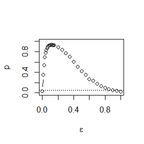

```r
alpha <-0.1;n <- 30;m <- 2500
epsilon <- c(seq(0, .14, .01), seq(.15, 1, .05));N <- length(epsilon);p <- numeric(N)
Ans2 <- function(d){
  cv<- qchisq(0.95,d*(d + 1)*(d + 2)/6)
  for (j in 1:N) {
    e <- epsilon[j]
    sktests <- numeric(m)
    for (i in 1:m) {
      s <- sample(c(1, 10), replace = TRUE,size = n*d, prob = c(1-e, e))
      X <- matrix(rnorm(n*d, 0, s),n,d)
      Xs<-scale(X)
      skm<-(tcrossprod(Xs,Xs))^3
      sk<-sum(skm)/(6*n)
      sktests[i] <- (abs(sk) >= cv)
    } ##重复m次
    p[j] <- mean(sktests)
  } ## epsilon结尾
  plot(epsilon, p, type = "b", xlab = bquote(epsilon), ylim = c(0,1))
  abline(h = alpha/2, lty = 3)
} ## 函数结尾

Ans2(2) ## 依次输出二三维的情况
```

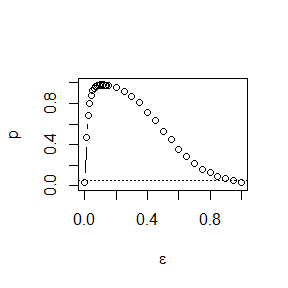

```r
Ans2(3)
```

## A-21039-2021-10-28

7.7&7.8&7.9

```r
library(boot)
library(MASS)
library(bootstrap)
data(scor, package = "bootstrap")
set.seed(666)
B<-2000
n<-nrow(scor)
theta.b<-numeric(B)
theta.jack<-numeric(n+1)
alpha<-0.05

for(i in 1:(n+1)){
  ev <- eigen(cov(scor[-i,]))
  theta.jack[i]<-(ev$values[1])/sum(ev$values)
  } ## jackknife

theta.hat<-theta.jack[n+1]
theta.jack<-theta.jack[-n-1]
bias.jack<-(n-1)*(theta.hat-mean(theta.jack))
se.jack<-(sd(theta.jack))*(n-1)/(n^0.5)

for(b in 1:B){
  i <- sample(1:n, size = n, replace = TRUE)
  ev <- eigen(cov(scor[i,]))
  theta.b[b]<-(ev$values[1])/sum(ev$values)
  } ## Bootstrap

bias.boot<-mean(theta.b-theta.hat)
se.boot<-sd(theta.b)

round(c(bias_boot=bias.boot,se_boot=se.boot,bias_jack=bias.jack,se_jack=se.jack),5) ##输出bootstrap和jackknife估计下偏差和标准差的估计
```

```
## bias_boot   se_boot bias_jack   se_jack
##   0.00125   0.04772  -0.00107   0.04955
```

```r
perc1 <- as.numeric(quantile(theta.b,alpha/2))
perc2 <- as.numeric(quantile(theta.b,1-alpha/2))

z0 <- qnorm(mean(theta.b<theta.hat))
a <- sum((mean(theta.jack)-theta.jack)^3)/6/sum(((mean(theta.jack)-theta.jack)^2)^1.5)
alpha1 <- pnorm(z0+(z0+qnorm(alpha/2))/(1-a*(z0+qnorm(alpha/2))))
alpha2 <- pnorm(z0+(z0+qnorm(1-alpha/2))/(1-a*(z0+qnorm(1-alpha/2))))

bca1 <- as.numeric(quantile(theta.b,alpha1))
bca2 <- as.numeric(quantile(theta.b,alpha2))

cat("Percentile CI:(",perc1,",",perc2,")") ## 输出percentile置信区间
```

```
## Percentile CI:( 0.520474 , 0.7057684 )
```

```r
cat("Bias-corrected and accelerated CI:(",bca1,",",bca2,")") ## 输出BCa置信区间
```

```
## Bias-corrected and accelerated CI:( 0.5281218 , 0.7162039 )
```

```r
library(moments)
set.seed(666)
sk1<-0
sk2<-(1.6)^0.5
n <- 100
B <- 1000
m <- 5000
alpha <- 0.05
ci.norm1<-ci.basic1<-ci.perc1<-matrix(0,m,2)
ci.norm2<-ci.basic2<-ci.perc2<-matrix(0,m,2)
sk1.b<-numeric(B)
sk2.b<-numeric(B)

for(i in 1:m){
  xx1<-rnorm(n)
  xx2<-rchisq(n,5)
  for(s in 1:B){
    sam1 <- sample(1:n, size = n, replace = TRUE)
    sk1.b[s] <- skewness(xx1[sam1])
  } ## bootstrap 1
  for(t in 1:B){
    sam2 <- sample(1:n, size = n, replace = TRUE)
    sk2.b[t] <- skewness(xx2[sam2])
  } ## bootstrap 2
  sk1.hat <- skewness(xx1)
  sk2.hat <- skewness(xx2)

  ci.norm1[i,1] <- sk1.hat-qnorm(1-alpha/2)*sd(sk1.b)
  ci.norm1[i,2] <- sk1.hat-qnorm(alpha/2)*sd(sk1.b)
  ci.norm2[i,1] <- sk2.hat-qnorm(1-alpha/2)*sd(sk2.b)
  ci.norm2[i,2] <- sk2.hat-qnorm(alpha/2)*sd(sk2.b)

  ci.basic1[i,1] <- 2*sk1.hat-as.numeric(quantile(sk1.b,1-alpha/2))
  ci.basic1[i,2] <- 2*sk1.hat-as.numeric(quantile(sk1.b,alpha/2))
  ci.basic2[i,1] <- 2*sk2.hat-as.numeric(quantile(sk2.b,1-alpha/2))
  ci.basic2[i,2] <- 2*sk2.hat-as.numeric(quantile(sk2.b,alpha/2))

  ci.perc1[i,1] <- as.numeric(quantile(sk1.b,alpha/2))
  ci.perc1[i,2] <- as.numeric(quantile(sk1.b,1-alpha/2))
  ci.perc2[i,1] <- as.numeric(quantile(sk2.b,alpha/2))
  ci.perc2[i,2] <- as.numeric(quantile(sk2.b,1-alpha/2))
} ## monte-carlo

norm1.left <- mean(sk1 < ci.norm1[,1] & sk1 < ci.norm1[,2])
norm1.right <- mean(sk1 > ci.norm1[,1] & sk1 > ci.norm1[,2])
norm2.left <- mean(sk2 < ci.norm2[,1] & sk2 < ci.norm2[,2])
norm2.right <- mean(sk2 > ci.norm2[,1] & sk2 > ci.norm2[,2])

basic1.left <- mean(sk1 < ci.basic1[,1] & sk1 < ci.basic1[,2])
basic1.right <- mean(sk1 > ci.basic1[,1] & sk1 > ci.basic1[,2])
basic2.left <- mean(sk2 < ci.basic2[,1] & sk2 < ci.basic2[,2])
basic2.right <- mean(sk2 > ci.basic2[,1] & sk2 > ci.basic2[,2])

perc1.left <- mean(sk1 < ci.perc1[,1] & sk1 < ci.perc1[,2])
perc1.right <- mean(sk1 > ci.perc1[,1] & sk1 > ci.perc1[,2])
perc2.left <- mean(sk2 < ci.perc2[,1] & sk2 < ci.perc2[,2])
perc2.right <- mean(sk2 > ci.perc2[,1] & sk2 > ci.perc2[,2])

c(norm.left=norm1.left,norm.right=norm1.right,basic.left=basic1.left,basic.right=basic1.right,perc.left=perc1.left,perc.right=perc1.right) ## 输出样本服从标准正态分布时的情形
```

```
##   norm.left  norm.right  basic.left basic.right   perc.left  perc.right
##      0.0400      0.0342      0.0492      0.0432      0.0328      0.0282
```

```r
c(norm.left=norm2.left,norm.right=norm2.right,basic.left=basic2.left,basic.right=basic2.right,perc.left=perc2.left,perc.right=perc2.right) ## 输出样本服从自由度为5的卡方分布时的情形
```

```
##   norm.left  norm.right  basic.left basic.right   perc.left  perc.right
##      0.0086      0.2216      0.0502      0.2080      0.0022      0.2432
```

从结果中我们可以看出这三种方法对卡方分布时右侧遗漏的概率远大于对正态分布的，对左侧而言normal和percentile CI下卡方分布左侧的遗漏率远小于正态的，basic CI时两者差不多。对于总体而言正态分布的覆盖率要好于卡方分布的。

## A-21039-2021-11-04

### Question

1.Exercise 8.2 (page 242, Statistical Computating with R).

2.Design experiments for evaluating the performance of the NN, energy, and ball methods in various situations.

I Unequal variances and equal expectations

I Unequal variances and unequal expectations

I Non-normal distributions: t distribution with 1 df (heavy-tailed distribution), bimodel distribution (mixture of two normal distributions)

I Unbalanced samples (say, 1 case versus 10 controls)

I Note: The parameters should be chosen such that the powers are distinguishable (say, range from 0.3 to 0.8).

### Answer

8.2

```r
Ans1 <- function(num,P){
  set.seed(666)
  xxx <- rnorm(num);yyy <- rnorm(num);zzz <- c(xxx,yyy)
  spearman_cor_test = cor.test(xxx, yyy, method = "spearman")
  myl <- rep(0,P);myl0 <- spearman_cor_test$estimate
  for(p in 1:P){
    sam <- sample(1:(2*num), size=num , replace=FALSE)
    xxx1 <- zzz[sam];yyy1 <- zzz[-sam]
    myl[p] <- cor(xxx1, yyy1, method = "spearman")
  } ## permutation test
  p <- mean((abs(c(myl0, myl)) - abs(myl0)) >= 0)
  round(c(p_value_cor=p,p_value_cor.test=spearman_cor_test$p.value),4)
} ## 输入num为两样本的样本元素个数，P为计算次数

Ans1(20,1e3-1) ##以元素样本量为20为例进行输出，通过几组实验认为当计算次数更多后用permutation得到的p值会更接近cor.test得到的p值
```

```
##      p_value_cor p_value_cor.test
##           0.2770           0.2584
```

```r
suppressWarnings(Ans1(20,1e4-1))
```

```
##      p_value_cor p_value_cor.test
##           0.2631           0.2584
```

```r
Ans1(20,1e5-1)
```

```
##      p_value_cor p_value_cor.test
##           0.2603           0.2584
```

homework2

I Unequal variances and equal expectations

```r
library(RANN)
library(boot)
library(energy)
library(Ball)

set.seed(666)
P<-1e2;alpha<-0.1
nr1 <- nr2<-50;nr <- nr1+nr2;NR <- c(nr1,nr2);sizes<-NR
k<-3;R<-999
p1<-p2<-p3<-rep(0,P)

Tn <- function(zz, sam,sizes,k) {
  nr1<-sizes[1];nr2 <- sizes[2];nr<-nr1+nr2
  if(is.vector(zz)) zz <- data.frame(zz,0)
  zz <- zz[sam, ]
  nntests <- nn2(data=zz, k=k+1)
  b1 <- nntests$nn.idx[1:nr1,-1]
  b2 <- nntests$nn.idx[(nr1+1):nr,-1]
  sum1 <- sum(b1 < nr1 + 0.5)
  sum2 <- sum(b2 > nr1 + 0.5)
  tn<-(sum1 +sum2) / (k * nr)
  return(tn)
} ## Tn函数在此结束

nn.test <- function(zz,sizes,k){
  objection <- boot(data=zz,statistic=Tn,R=R,sim = "permutation",sizes = sizes,k=k)
  aa <- c(objection$t0,objection$t)
  value_of_p <- mean(aa>=aa[1])
  list(statistic=aa[1],p.value=value_of_p)
} ## nn函数在此结束

for(j in 1:P){
  xx <- matrix(rnorm(2*nr1,0,1),nr1,2)
  yy <- matrix(rnorm(2*nr2,0,1.38),nr2,2)
  zz <- rbind(xx,yy)
  p1[j] <- nn.test(zz,NR,k)$p.value
  p2[j] <- eqdist.etest(zz,sizes=NR,R=R)$p.value
  p3[j] <- bd.test(xx,yy,num.permutations=999,seed=j*666)$p.value
}
pow1 <- mean(p1<alpha)
pow2 <- mean(p2<alpha)
pow3 <- mean(p3<alpha)
round(c(NN=pow1,Energy=pow2,Ball=pow3),4) ##输出三种方法的power
```

```
##     NN Energy   Ball
##   0.32   0.42   0.78
```

I Unequal variances and unequal expectations

```r
set.seed(666)
P<-1e2;alpha<-0.1
nr1 <- nr2<-50;nr <- nr1+nr2;NR <- c(nr1,nr2);sizes<-NR
k<-3;R<-999
p1<-p2<-p3<-rep(0,P)

Tn <- function(zz, sam,sizes,k) {
  nr1<-sizes[1];nr2 <- sizes[2];nr<-nr1+nr2
  if(is.vector(zz)) zz <- data.frame(zz,0)
  zz <- zz[sam, ]
  nntests <- nn2(data=zz, k=k+1)
  b1 <- nntests$nn.idx[1:nr1,-1]
  b2 <- nntests$nn.idx[(nr1+1):nr,-1]
  sum1 <- sum(b1 < nr1 + 0.5)
  sum2 <- sum(b2 > nr1 + 0.5)
  tn<-(sum1 +sum2) / (k * nr)
  return(tn)
} ## Tn函数在此结束

nn.test <- function(zz,sizes,k){
  objection <- boot(data=zz,statistic=Tn,R=R,sim = "permutation",sizes = sizes,k=k)
  aa <- c(objection$t0,objection$t)
  value_of_p <- mean(aa>=aa[1])
  list(statistic=aa[1],p.value=value_of_p)
} ## nn函数在此结束

for(j in 1:P){
  xx <- matrix(rnorm(2*nr1,0.25,1),nr1,2)
  yy <- matrix(rnorm(2*nr2,0,1.38),nr2,2)
  zz <- rbind(xx,yy)
  p1[j] <- nn.test(zz,NR,k)$p.value
  p2[j] <- eqdist.etest(zz,sizes=NR,R=R)$p.value
  p3[j] <- bd.test(xx,yy,num.permutations=999,seed=j*666)$p.value
}
pow1 <- mean(p1<alpha)
pow2 <- mean(p2<alpha)
pow3 <- mean(p3<alpha)
round(c(NN=pow1,Energy=pow2,Ball=pow3),4) ##输出三种方法的power
```

```
##     NN Energy   Ball
##   0.44   0.62   0.86
```

I Non-normal distributions: t distribution with 1 df (heavy-tailed distribution), bimodel distribution (mixture of two normal distributions)

```r
set.seed(666)
P<-1e2;alpha<-0.1
nr1 <- nr2<-50;nr <- nr1+nr2;NR <- c(nr1,nr2);sizes<-NR
k<-3;R<-999
p1<-p2<-p3<-rep(0,P)

Tn <- function(zz, sam,sizes,k) {
  nr1<-sizes[1];nr2 <- sizes[2];nr<-nr1+nr2
  if(is.vector(zz)) zz <- data.frame(zz,0)
  zz <- zz[sam, ]
  nntests <- nn2(data=zz, k=k+1)
  b1 <- nntests$nn.idx[1:nr1,-1]
  b2 <- nntests$nn.idx[(nr1+1):nr,-1]
  sum1 <- sum(b1 < nr1 + 0.5)
  sum2 <- sum(b2 > nr1 + 0.5)
  tn<-(sum1 +sum2) / (k * nr)
  return(tn)
} ## Tn函数在此结束

nn.test <- function(zz,sizes,k){
  objection <- boot(data=zz,statistic=Tn,R=R,sim = "permutation",sizes = sizes,k=k)
  aa <- c(objection$t0,objection$t)
  value_of_p <- mean(aa>=aa[1])
  list(statistic=aa[1],p.value=value_of_p)
} ## nn函数在此结束

for(j in 1:P){
  xx <- matrix(rt(2*nr1,1),nr1,2)
  bi <- as.numeric(runif(2*nr2)>0.5)
  bimodel <- bi*rnorm(2*nr2,-1,2)+(1-bi)*rnorm(2*nr2,1,2)
  yy <- matrix(bimodel,nr2,2)
  zz <- rbind(xx,yy)
  p1[j] <- nn.test(zz,NR,k)$p.value
  p2[j] <- eqdist.etest(zz,sizes=NR,R=R)$p.value
  p3[j] <- bd.test(xx,yy,num.permutations=999,seed=j*666)$p.value
}
pow1 <- mean(p1<alpha)
pow2 <- mean(p2<alpha)
pow3 <- mean(p3<alpha)
round(c(NN=pow1,Energy=pow2,Ball=pow3),4) ##输出三种方法的power
```

```
##     NN Energy   Ball
##   0.60   0.56   0.47
```

I Unbalanced samples (say, 1 case versus 10 controls)

```r
set.seed(666)
P<-1e2;alpha<-0.1
nr1 <-10; nr2<-90; nr <- nr1+nr2;NR <- c(nr1,nr2);sizes<-NR
k<-3;R<-999
p1<-p2<-p3<-rep(0,P)

Tn <- function(zz, sam,sizes,k) {
  nr1<-sizes[1];nr2 <- sizes[2];nr<-nr1+nr2
  if(is.vector(zz)) zz <- data.frame(zz,0)
  zz <- zz[sam, ]
  nntests <- nn2(data=zz, k=k+1)
  b1 <- nntests$nn.idx[1:nr1,-1]
  b2 <- nntests$nn.idx[(nr1+1):nr,-1]
  sum1 <- sum(b1 < nr1 + 0.5)
  sum2 <- sum(b2 > nr1 + 0.5)
  tn<-(sum1 +sum2) / (k * nr)
  return(tn)
} ## Tn函数在此结束

nn.test <- function(zz,sizes,k){
  objection <- boot(data=zz,statistic=Tn,R=R,sim = "permutation",sizes = sizes,k=k)
  aa <- c(objection$t0,objection$t)
  value_of_p <- mean(aa>=aa[1])
  list(statistic=aa[1],p.value=value_of_p)
} ## nn函数在此结束

for(j in 1:P){
  xx <- matrix(rnorm(2*nr1,0,1),nr1,2)
  yy <- matrix(rnorm(2*nr2,0,2),nr2,2)
  zz <- rbind(xx,yy)
  p1[j] <- nn.test(zz,NR,k)$p.value
  p2[j] <- eqdist.etest(zz,sizes=NR,R=R)$p.value
  p3[j] <- bd.test(xx,yy,num.permutations=999,seed=j*666)$p.value
}
pow1 <- mean(p1<alpha)
pow2 <- mean(p2<alpha)
pow3 <- mean(p3<alpha)
round(c(NN=pow1,Energy=pow2,Ball=pow3),4) ##输出三种方法的power
```

```
##     NN Energy   Ball
##   0.25   0.12   0.98
```

## A-21039-2021-11-11

### Question

1.Exercies 9.3 and 9.8 (pages 277-278, Statistical Computating with R).

2.For each of the above exercise, use the Gelman-Rubin method to monitor convergence of the chain, and run the chain until it converges approximately to the target distribution according to $\hat R$ < 1.2.

### Answer

9.3 & Monitoring convergence

在本题中提议分布我取了$N(X_t,\sigma^2)$来生成样本,$\sigma$的值最后选用的为2.5.

```r
set.seed(666)
rw.Metropolis <- function(sigma, x0, N){
  xt <- rep(0,N)
  xt[1] <- x0
  k <- 0
  u <- runif(N)
  for (s in 2:N) {
    y <- rnorm(1, xt[s-1], sigma)
        if (u[s] > (dcauchy(y) / dcauchy(xt[s-1]))){
          xt[s] <- xt[s-1]; k <-k+1
        }
        else {
          xt[s] <- y
          } ## 赋值
        } ##游走
  return(list(x=xt, k=k))
} ##函数

N <- 15000
sigma <- 2.5
x0 <- c(-10, -5, 5, 10)
rw1 <- rw.Metropolis(sigma, x0[1], N)
rw2 <- rw.Metropolis(sigma, x0[2], N)
rw3 <- rw.Metropolis(sigma, x0[3], N)
rw4 <- rw.Metropolis(sigma, x0[4], N)

## print(c(rw1$k, rw2$k, rw3$k, rw4$k)/N) ##输出这四个链的拒绝概率

rw <- cbind(rw1$x, rw2$x, rw3$x, rw4$x)
b <- 1001 ##buring sample
a <- seq(0.1,0.9,0.1)
Q <- qcauchy(a)
mc <- rw[b:N,]
Qrw <- apply(mc,2,function(x) quantile(x,a))
QQ <- cbind(Q, Qrw)
colnames(QQ) <- c("Cauchy Quantiles", "chain1", "chain2", "chain3", "chain4")
print(round(QQ, 3)) ## 理论分位数与样本分位数的比较
```

```
##     Cauchy Quantiles chain1 chain2 chain3 chain4
## 10%           -3.078 -3.103 -2.795 -2.894 -2.348
## 20%           -1.376 -1.342 -1.322 -1.376 -1.182
## 30%           -0.727 -0.705 -0.715 -0.749 -0.650
## 40%           -0.325 -0.324 -0.359 -0.344 -0.293
## 50%            0.000  0.017 -0.052 -0.034  0.018
## 60%            0.325  0.309  0.288  0.292  0.320
## 70%            0.727  0.685  0.645  0.686  0.677
## 80%            1.376  1.278  1.190  1.332  1.275
## 90%            3.078  2.725  2.485  2.876  2.568
```

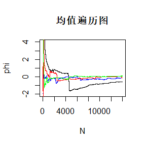

```r
erg.mean <- function(x){
  lx <- length(x)
  result <-cumsum(x)/c(1:lx)
  return(result)
  }

phimc <- apply(mc, 2, erg.mean)
plot(phimc[,1],type="l", xlab='N', ylab="phi",ylim=c(-2,4),main='均值遍历图')
lines(phimc[,2],type="l", col='blue')
lines(phimc[,3],type="l", col='red')
lines(phimc[,4],type="l", col='green')
```

```r
ww <- function(x){
  result <- sum((x-mean(x))^2)
  return(result)
  }

n <- nrow(phimc)
bn <- n/3*sum((colMeans(phimc)-mean(phimc))^2)
wn <- 1/4/n*sum(apply(phimc, 2, ww))
hat_r <- round(1-1/n+bn/wn/n,3)
cat("Gelman-Rubin统计量为",hat_r,"小于 1.2 ,因此符合监视收敛要求")
```

```
## Gelman-Rubin统计量为 1.01 小于 1.2 ,因此符合监视收敛要求
```

9.8 & Monitoring convergence

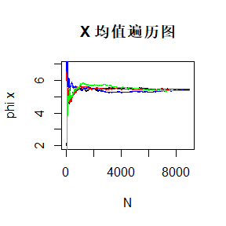

```r
rm(list = ls())
set.seed(666)
alpha <-2; n<- 16; beta <-4

gibbs <- function(x0, y0, N){
  xyg <- matrix(0, N, 2)
  xyg[1,1] <- x0
  xyg[1,2] <- y0
  for(t in 2:N){
    xyg[t,1] <- rbinom(1, n, xyg[t-1,2])
    xyg[t,2] <- rbeta(1, xyg[t,1]+alpha, -xyg[t,1]+n+beta)
  } ## 赋值
  return(xyg)
} ## 函数

N <- 10000
x0 <- c(4, 3, 6, 2)
y0 <- c(0.3, 0.2, 0.5, 0.4)
xy1 <- gibbs(x0[1], y0[1], N)
xy2 <- gibbs(x0[2], y0[2], N)
xy3 <- gibbs(x0[3], y0[3], N)
xy4 <- gibbs(x0[4], y0[4], N)

## f <- function(x){den <- gamma(n+1)/gamma(x[1]+1)/gamma(n-x[1]+1)*(x[2])^(x[1]+alpha-1)*(1-x[2])^(n-x[1]+beta-1);return(den)}

phix <- cbind(xy1[,1], xy2[,1], xy3[,1], xy4[,1])
b <- 1001

phix <- phix[b:N,]

erg.mean <- function(x){
  lx <- length(x)
  result <-cumsum(x)/c(1:lx)
  return(result)
  }

phimc <- apply(phix, 2, erg.mean)
plot(phimc[,1],type="l", xlab='N', ylab="phi x",main='X 均值遍历图')
lines(phimc[,2],type="l", col='blue')
lines(phimc[,3],type="l", col='red')
lines(phimc[,4],type="l", col='green')
```

```r
ww <- function(x){
  result <- sum((x-mean(x))^2)
  return(result)
  }

n <- nrow(phimc)
bn1 <- n/3*sum((colMeans(phimc)-mean(phimc))^2)
wn1 <- 1/4/n*sum(apply(phimc, 2, ww))
hat_r1 <- round(1-1/n+bn1/wn1/n,3)
cat("Gelman-Rubin统计量为",hat_r1,"小于 1.2 ,因此X分量符合监视收敛要求")
```

```
## Gelman-Rubin统计量为 1.043 小于 1.2 ,因此X分量符合监视收敛要求
```

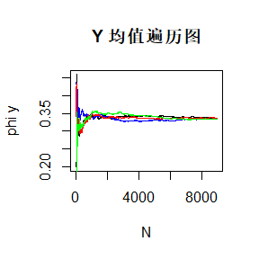

```r
####

phiy<- cbind(xy1[,2], xy2[,2], xy3[,2], xy4[,2])
b <- 1001

phiy <- phiy[b:N,]

erg.mean <- function(x){
  lx <- length(x)
  result <-cumsum(x)/c(1:lx)
  return(result)
  }

phimc <- apply(phiy, 2, erg.mean)
plot(phimc[,1],type="l", xlab='N', ylab="phi y",main='Y 均值遍历图')
lines(phimc[,2],type="l", col='blue')
lines(phimc[,3],type="l", col='red')
lines(phimc[,4],type="l", col='green')
```

```r
ww <- function(x){
  result <- sum((x-mean(x))^2)
  return(result)
  }

n <- nrow(phimc)
bn2 <- n/3*sum((colMeans(phimc)-mean(phimc))^2)
wn2 <- 1/4/n*sum(apply(phimc, 2, ww))
hat_r2 <- round(1-1/n+bn2/wn2/n,3)
cat("Gelman-Rubin统计量为",hat_r2,"小于 1.2 ,因此y分量符合监视收敛要求")
```

```
## Gelman-Rubin统计量为 1.048 小于 1.2 ,因此y分量符合监视收敛要求
```

## A-21039-2021-11-18

### Question

I.Exercises 11.3 and 11.5 (pages 353-354, Statistical Computing with R)

II Suppose $T_1,\cdots,T_n$ are i.i.d. samples drawn from the exponential distribution with expectation $\lambda$. Those values greater than $\tau$ are not observed due to right censorship, so that the observed values are $Y_i=T_iI(T_i\le\tau)+\tau I(T_i\gt\tau), i=1,2,\cdots,n$. Suppose $\tau=1$ and the observed $Y_i$ values are as follows:
$$0.54, 0.48, 0.33, 0.43, 1.00, 1.00, 0.91, 1.00, 0.21, 0.85$$
Use the E-M algorithm to estimate $\lambda$, compare your result with the observed data MLE (note: $Y_i$ follows a mixture distribution).

### Answer

11.3

```r
Term <- function(va, k){
  a <- sum(va^2)
  d <- length(va)
  term <- a*(-a/2)^k/(2*k+1)/(2*k+2)*exp(lgamma((d+1)/2)+lgamma(k+1.5)-lgamma(k+d/2+1)-lgamma(k+1))
  return(term)
} ## 生成第k个的系数

va <- c(1,2)

Ans1 <- function(k){Term(va,k)} ##以具体的a为例输出系数

cat("此次计算中最后一个能被计算大于0的系数为k=176时，此时系数为:",Ans1(176),"\n而k大于等于177之后系数的值过小而无法计算,k=177时系数为:",Ans1(177))
```

```
## 此次计算中最后一个能被计算大于0的系数为k=176时，此时系数为: 1.465302e-256
## 而k大于等于177之后系数的值过小而无法计算,k=177时系数为: 0
```

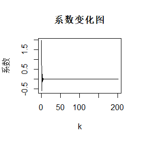

```r
Ans2 <- function(n){
  x <- matrix(c(0:n),1,n+1)
  s <- sum(apply(x,2,Ans1))
  return(s)
} ## 输出k从0到n时系数之和

N <- 200
sam <- matrix(c(0:N),1,N+1)
x1 <- apply(sam,2,Ans1)
x2 <- apply(sam,2,Ans2)

plot(x1,type="l", xlab='k', ylab="系数",main='系数变化图')
```

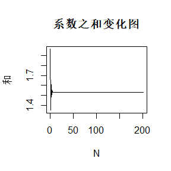

```r
plot(x2,type="l", xlab='N', ylab="和",main='系数之和变化图')
```

```r
cat("因此总和为:",Ans2(200))
```

```
## 因此总和为: 1.532164
```

11.5

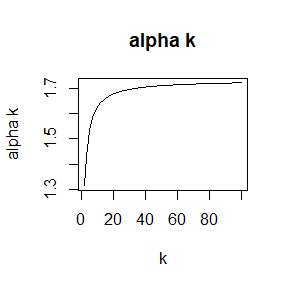

```r
rm(list = ls())

cc <- function(k,a){((a^2*k)/(k+1-a^2))^0.5}
f <- function(k,a){
  Int <- function(u){
    y <- (1+u^2/k)^((k+1)/(-2))
    return(y)
  } ## 积分内部用的函数
  inc <- integrate(Int,0,cc(k,a))$value
  yy <- 2*inc/(pi*k)^0.5*exp(lgamma((k+1)/2)-lgamma(k/2))
  return(yy)
} ## f(k)=f(k-1)

alpha <- function(k){
  sol <- function(a){
    re <- f(k,a)-f(k-1,a)
    return(re)
  } ##要解的方程
  hh <- 1.4*as.numeric(k==2)+1.7*as.numeric(k==3)+2*as.numeric(k>3) ## 搞个满足uniroot条件的上界
  solution <- uniroot(sol,c(0.1,hh),tol=0.001)$root
  return(solution)
} #求解alpha k,此时解出的解为正解，相应的对于每个k,alpha还有个相反数同样为解,同时0也为解

N <- 100
sam <- matrix(c(2:N),1)
ak <- apply(sam, 2, alpha)
plot(sam,ak,type="l", xlab='k', ylab="alpha k",main='alpha k')
```

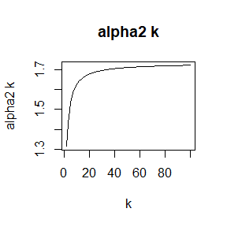

```r
#接下来求解11.4题

alpha2 <- function(k){
  sol2 <- function(a){
    re <- pt(cc(k,a),k)-pt(cc(k-1,a),k-1)
    return(re)
  }
  hh <- 1.4*as.numeric(k==2)+1.7*as.numeric(k==3)+2*as.numeric(k>3) ## 搞个满足uniroot条件的上界
  solution <- uniroot(sol2,c(0.1,hh),tol=0.001)$root
  return(solution)
}

ak2 <- apply(sam, 2, alpha2)
plot(sam,ak2,type="l", xlab='k', ylab="alpha2 k",main='alpha2 k')
```

```r
cat("两方法解出来的alpha(k)在程序中计算值差值最大为:",max(abs(ak2-ak)),",非常的小.")
```

```
## 两方法解出来的alpha(k)在程序中计算值差值最大为: 2.445025e-09 ,非常的小.
```

Homework 3

记观测的样本值为$t_1,\cdots,t_n$,未观测到的样本值为$s_1,\cdots,s_m$.但由于知道未观测到样本值有信息$w_1,\cdots,w_m$代表着$s_1,\cdots,s_m$均大于1.因此此时的似然函数为:

$$L(\lambda;\boldsymbol{t},\boldsymbol{s},\boldsymbol{w})=\frac{1}{\lambda^{n+m}}exp\{\frac{\sum_{k=1}^nt_k+\sum_{k=1}^ms_k}{-\lambda}\}·\prod_{k=1}^mI(s_k\gt1)$$

则E-M算法中的E步为:

$$\begin{equation}\begin{split}
l_0(\lambda;\boldsymbol{t},\boldsymbol{s},\boldsymbol{w})&=E_{\lambda_0}[logL(\lambda;\boldsymbol{t},\boldsymbol{s},\boldsymbol{w})|\boldsymbol{t},\boldsymbol{w}] \\
&= -(n+m)ln\lambda-\frac{\sum_{k=1}^nt_k+\sum_{k=1}^mE_{\lambda_0}[s_k|\boldsymbol{t},\boldsymbol{w}]}{\lambda} \\
&= -(n+m)ln\lambda-\frac{\sum_{k=1}^nt_k+m(\lambda_0+1)}{\lambda}
\end{split}\end{equation}$$

M步，下对似然函数求导则

$$\frac{\partial l_0(\lambda;\boldsymbol{t},\boldsymbol{s},\boldsymbol{w})}{\partial \lambda}=-\frac{n+m}{\lambda}+\frac{\sum_{k=1}^nt_k+m(\lambda_0+1)}{\lambda^2}$$

这个偏导随$\lambda$增大而先正后负，因此为使似然函数最大的$\lambda_1=\frac{\sum_{k=1}^nt_k+m(\lambda_0+1)}{n+m}$

对于这个简单的递归形式我们可以得到$\lambda$最终收敛$\lambda^*=\frac{m+\sum_{k=1}^nt_k}{n}$,代入数据即得到$\lambda^*=0.9643$

而在本题中通过观察值得到的MLE由下给出，此时似然函数为

$$L(\lambda;\boldsymbol{t},\boldsymbol{w})=\frac{1}{\lambda^{n}}exp\{\frac{\sum_{k=1}^nt_k}{-\lambda}\}·e^{-\frac{m}{\lambda}}$$

取对数后求导得到:

$$\frac{\partial l(\lambda;\boldsymbol{t},\boldsymbol{w})}{\partial \lambda}=-nln\lambda-\frac{m+\sum_{k=1}^nt_k}{\lambda}$$

因此

$$\lambda_{MLE}=\frac{m+\sum_{k=1}^nt_k}{n}=0.9643$$

也就是说此时由E-M算法的得到的$\lambda$在迭代后将收敛到由极大似然估计得到的结果.

```r
rm(list = ls())
sam <- c(0.54, 0.48, 0.33, 0.43, 1.00, 1.00, 0.91, 1.00, 0.21, 0.85)
result <- round(sum(sam)/7,4)
cat("lambda收敛于:",result)
```

```
## lambda收敛于: 0.9643
```

## A-21039-2021-11-25

### Question

Exercises 1 and 5 (page 204, Advanced R)

Excecises 1 and 7 (page 214, Advanced R)

### Answer

11.1.2.1

由lapply的定义知道第一种方法的结果等于下式输出的”out1”.

```r
set.seed(666)
trims <- c(0, 0.1, 0.2, 0.5)
x <- rcauchy(100)

out1 <- vector("list", length(trims))
f <- function(trim) mean(x, trim = trim)
for (i in seq_along(trims)) {
out1[[i]] <- f(trims[i])
}
```

而第二种方法的结果由定义知等于下式输出的”out2”.

```r
set.seed(666)
trims <- c(0, 0.1, 0.2, 0.5)
x <- rcauchy(100)

out2 <- vector("list", length(trims))
for (i in seq_along(trims)) {
out2[[i]] <- mean(trims[i], x=x)
}
```

由于用用参数名指定了变量，因此对函数mean的两个参数在写法上可交换位置，上式两种方法实现的都是在去掉x的最大最小的trims[i]比例的值后计算均值，并将结果存为列表.

11.1.2.5

```r
set.seed(666)
attach(mtcars)
formulas <- list(
  mpg ~ disp,
  mpg ~ I(1 / disp),
  mpg ~ disp + wt,
  mpg ~ I(1 / disp) + wt
)

MOD <- lapply(formulas, lm)
rsq <- function(mod) summary(mod)$r.squared
r2 <- lapply(MOD, rsq)
cat("四种模型的R方为",unlist(r2))
```

```
## 四种模型的R方为 0.7183433 0.8596865 0.7809306 0.8838038
```

```r
bootstraps <- lapply(1:10, function(i) {
  rows <- sample(1:nrow(mtcars), rep = TRUE)
  mpg[rows] ~ disp[rows]
})

MOD2 <- lapply(bootstraps, lm)
r22 <- lapply(MOD2, rsq)
cat("十次Bootstrap下的的R方为",unlist(r22))
```

```
## 十次Bootstrap下的的R方为 0.7293527 0.7605726 0.751088 0.7390096 0.5371709 0.6009097 0.7371936 0.7672648 0.7582207 0.6634633
```

11.2.5.1

```r
set.seed(666)

x <- rnorm(1000)
df <- data.frame(replicate(20, sample(x, 100, replace = TRUE)))
sd1 <- vapply(df, sd, numeric(1))

cat("data.frame全为数值的例子下，计算各列的标准差为:",unlist(sd1))
```

```
## data.frame全为数值的例子下，计算各列的标准差为: 0.896058 0.9481209 0.8776343 1.06684 1.001225 0.9172064 0.9010398 0.9908133 0.8920251 0.9912077 1.002891 0.9699755 0.9083458 0.9378016 0.9809335 0.8868376 0.9318921 0.9975368 0.9235961 0.9629849
```

```r
df2 <- data.frame(replicate(20, sample(x, 100, replace = TRUE)),replicate(10, letters[sample(c(1:26), 100, replace = TRUE)]))
resam <- sample(c(1:ncol(df2)))
df2 <- df2[,resam] ## 打乱列的顺序

che <- vapply(df2, is.numeric, logical(1))
df3 <- df2[unlist(che)]
sd2 <- vapply(df3, sd, numeric(1))
cat("data.frame不全为数值的例子下，计算数字各列的标准差为:",unlist(sd2))
```

```
## data.frame不全为数值的例子下，计算数字各列的标准差为: 0.8918482 1.010521 1.170578 1.005266 1.035716 1.045728 1.039386 0.9620407 0.9314036 0.9769994 1.050323 0.8823836 1.019527 0.9696618 0.9553394 1.024069 1.158256 0.9620932 1.026816 0.9040711
```

11.2.5.7

```r
mcsapply <- function(X, FUN, ..., simplify = TRUE, USE.NAMES = TRUE) {
  FUN <- match.fun(FUN)
  answer <- parallel::mclapply(X = X, FUN = FUN, ...)
  if (USE.NAMES && is.character(X) && is.null(names(answer)))
      names(answer) <- X
  if (!identical(simplify, FALSE) && length(answer))
      simplify2array(answer, higher = (simplify == "array"))
  else answer
}
```

而mcvapply无法类似的实现.

## A-21039-2021-12-02

### Question

Write an Rcpp function for Exercise 9.8 (page 278, Statistical Computing with R).

Compare the corresponding generated random numbers with pure R language using the function “qqplot”.

Campare the computation time of the two functions with the function “microbenchmark”.

Comments your results.

### Answer

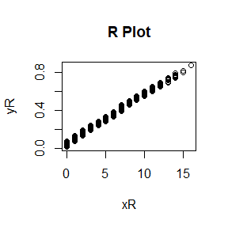

```r
library(Rcpp)
library(microbenchmark)
set.seed(666)

cppFunction('NumericMatrix gibbsC(int N, int thin, int a, int b, int n) {
  NumericMatrix mat(N, 2);
  double x = 0, y = 0.5;
  for(int i = 0; i < N; i++) {
    for(int j = 0; j < thin; j++) {
      x = rbinom(1, n, y)[0];
      y = rbeta(1, x + a, n - x + b)[0];
    }
    mat(i, 0) = x;
    mat(i, 1) = y;
  }
  return(mat);
}')

gibbsR <- function(N, thin, a, b, n){
  mat <- matrix(nrow = N, ncol = 2)
  x <- 0
  y <- 0.5
  for (i in 1:N) {
    for (j in 1:thin) {
      x <- rbinom(1, n, y)
      y <- rbeta(1, x + a, n - x + b)
    }
    mat[i, ] <- c(x, y)
  }
  return(mat)
}

a <- 2
b <- 4
n <- 16

gibbR = gibbsR(1000, 10, a, b, n)
gibbC = gibbsC(1000, 10, a, b, n)

xR <- gibbR[,1]
yR <- gibbR[,2]
xC <- gibbC[,1]
yC <- gibbC[,2]
qqplot(xR, yR, main='R Plot')
```

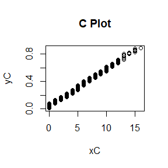

```r
qqplot(xC, yC, main='C Plot')
```

```r
ts <- microbenchmark(gibbR = gibbsR(1000, 10, a, b, n),
                     gibbC = gibbsC(1000, 10, a, b, n))

summary(ts)[,c(1,3,5,6)]
```

```
##    expr       lq   median       uq
## 1 gibbR 44.86325 45.38810 46.12045
## 2 gibbC  3.54190  3.60285  3.82995
```